# 01. DataLoader - first steps

Roberto Gatta

14/01/2022

# 1 Introduction

**dataLoader** is one of the most important classes in pMineR. It represents the interface between the data and all the other classes. Each other class, in pMineR, can interact with the Event Log only by the methdod dataLoader::getData().

The most important methods are, in the current version, the following:

- *dataLoader::load.csv()* : to load the Event Log stored in a csv file stored on the local filesystem
- *dataLoader::load.data.frame()* : to load an Event Log stored in a data.frame, in the R environment.
- *dataLoader::getData()* : to get the the Event Log in a shape which can be sent in input to other classes.
- *dataLoader::applyFilter()* : to filter the previously loaded Event Log (by PatientID, kind of Event, attributes, etc..) and generate a new Event Log or a new *dataLoder object.

## 1.1 Data Loading

Let’s consider the following CSV, containing the Event Log we might want to load:

| ID | Event | Date | Sex |
| --- | --- | --- | --- |
| 1 | Medical Visit | 2001-01-04 | M |
| 1 | Imaging | 2001-01-11 | M |
| 1 | Imaging | 2001-01-16 | M |
| 1 | Imaging | 2001-01-19 | M |
| 1 | Medical Visit | 2001-01-21 | M |
| 1 | Imaging | 2001-01-31 | M |
| 1 | Biopsy | 2001-02-08 | M |
| 1 | partial resection | 2001-02-12 | M |
| 1 | death | 2001-02-17 | M |
| 2 | Imaging | 2001-01-09 | M |
| 2 | Imaging | 2001-01-14 | M |
| 2 | Imaging | 2001-01-19 | M |
| 2 | Imaging | 2001-01-27 | M |
| 2 | Medical Visit | 2001-02-05 | M |
| 2 | Medical Visit | 2001-02-07 | M |

We can instantiate an object end exploit the method *dataLoader::load.csv()* to load the csv. This method takes in input the parameters needed to declare the role of each field (ID, date, Event) and the data format. Pay attention to the data format: separators too **must** be indicated (e.g. “-”, “/”, etc.. )

```r
objDL <- dataLoader(verbose.mode = FALSE)
objDL$load.csv(nomeFile = "../dataS/four.generated.csv",sep = ";",IDName = "ID",EVENTName = "Event",dateColumnName = "Date",format.column.date = "%Y-%m-%d")
```

## 1.2 Getting the output

Once loaded, the EL can be exported and sent in input to the other pMineR’s classes. This can be easily done with the method *dataLoder::getData()* in the following easy way:

```r
objDL.out <- objDL$getData()
```

Now the variable *objDL.out* is a list containing many usesul information. The *objDL.out* list is indexed with the following keys:

- *arrayAssociativo* : contains the set of events retrieved from the Event Log;
- *MMatrix* : is the matrix containing the absolute count of the subsequent movement from an Event to the following. Here two *virtual events* are added: *BEGIN* and *END* and are forced to be the begin and the end of all the traces in the Event Log. For example:

|  | BEGIN | END | Medical Visit | Imaging | Biopsy | partial resection | death | chemotherapy | radiotherapy | total resection |
| --- | --- | --- | --- | --- | --- | --- | --- | --- | --- | --- |
| BEGIN | 0 | 0 | 51 | 49 | 0 | 0 | 0 | 0 | 0 | 0 |
| END | 0 | 0 | 0 | 0 | 0 | 0 | 0 | 0 | 0 | 0 |
| Medical Visit | 0 | 2 | 111 | 59 | 50 | 0 | 45 | 0 | 0 | 0 |
| Imaging | 0 | 0 | 62 | 64 | 37 | 0 | 9 | 0 | 0 | 0 |
| Biopsy | 0 | 0 | 0 | 0 | 0 | 49 | 5 | 0 | 0 | 33 |
| partial resection | 0 | 0 | 12 | 0 | 0 | 0 | 14 | 17 | 6 | 0 |
| death | 0 | 98 | 0 | 0 | 0 | 0 | 0 | 0 | 0 | 0 |
| chemotherapy | 0 | 0 | 7 | 0 | 0 | 0 | 2 | 51 | 10 | 0 |
| radiotherapy | 0 | 0 | 16 | 0 | 0 | 0 | 1 | 0 | 132 | 0 |
| total resection | 0 | 0 | 8 | 0 | 0 | 0 | 22 | 2 | 1 | 0 |

- *MMatrix.perc* : is the *MMatrix* matrix where each line is normalised to have a sum equal to one. In other words, it contains the *probability* to jump from a state to another one as next step. Here there is an example:

|  | BEGIN | END | Medical Visit | Imaging | Biopsy | partial resection | death | chemotherapy | radiotherapy | total resection |
| --- | --- | --- | --- | --- | --- | --- | --- | --- | --- | --- |
| BEGIN | 0 | 0.0000000 | 0.5100000 | 0.4900000 | 0.0000000 | 0.0000000 | 0.0000000 | 0.0000000 | 0.0000000 | 0.0000000 |
| END | 0 | 0.0000000 | 0.0000000 | 0.0000000 | 0.0000000 | 0.0000000 | 0.0000000 | 0.0000000 | 0.0000000 | 0.0000000 |
| Medical Visit | 0 | 0.0074906 | 0.4157303 | 0.2209738 | 0.1872659 | 0.0000000 | 0.1685393 | 0.0000000 | 0.0000000 | 0.0000000 |
| Imaging | 0 | 0.0000000 | 0.3604651 | 0.3720930 | 0.2151163 | 0.0000000 | 0.0523256 | 0.0000000 | 0.0000000 | 0.0000000 |
| Biopsy | 0 | 0.0000000 | 0.0000000 | 0.0000000 | 0.0000000 | 0.5632184 | 0.0574713 | 0.0000000 | 0.0000000 | 0.3793103 |
| partial resection | 0 | 0.0000000 | 0.2448980 | 0.0000000 | 0.0000000 | 0.0000000 | 0.2857143 | 0.3469388 | 0.1224490 | 0.0000000 |
| death | 0 | 1.0000000 | 0.0000000 | 0.0000000 | 0.0000000 | 0.0000000 | 0.0000000 | 0.0000000 | 0.0000000 | 0.0000000 |
| chemotherapy | 0 | 0.0000000 | 0.1000000 | 0.0000000 | 0.0000000 | 0.0000000 | 0.0285714 | 0.7285714 | 0.1428571 | 0.0000000 |
| radiotherapy | 0 | 0.0000000 | 0.1073826 | 0.0000000 | 0.0000000 | 0.0000000 | 0.0067114 | 0.0000000 | 0.8859060 | 0.0000000 |
| total resection | 0 | 0.0000000 | 0.2424242 | 0.0000000 | 0.0000000 | 0.0000000 | 0.6666667 | 0.0606061 | 0.0303030 | 0.0000000 |

- *MMatrix.perc.noLoop* : is similar to the *MMatrix.perc* but here all the “loop” were removed. This means that any jump from a state x to a state x has been set to 0. This can be useful when the dataset is full of unwished loops, for example due to a high granularity of the event such as the “lab exam”. This additional matrix is provided because in some cases, the high granularity of the Event Log would make preferrable to suppress the information about loops.
- *pat.process* : this is a list indexed by the Patient ID indicated as *IDName* in the dataLoader::load.csv() method used to load the data. Each element of this list contains the subset of the Event Log, ordered by date, concerning a specific patient. In this subset two new colums are added: *pMineR.internal.ID.Evt* which is an ID for pMineR internal use and **pMineR.deltaDate** which counts, in minutes, how far is each line from the first event. This last field, in particular, can be **very useful*. Here there is, for example, the table of a patient:

|  | pMineR.internal.ID.Evt | ID | Event | Date | Sex | pMineR.deltaDate |
| --- | --- | --- | --- | --- | --- | --- |
| 922 | 922 | 100 | Medical Visit | 06/01/2001 00:00:00 | M | 0 |
| 923 | 923 | 100 | Biopsy | 11/01/2001 00:00:00 | M | 7200 |
| 924 | 924 | 100 | total resection | 27/01/2001 00:00:00 | M | 30240 |
| 925 | 925 | 100 | death | 08/02/2001 00:00:00 | M | 47520 |

```r
objDL.out$wordSequence.raw$`54`
```

```
##  [1] "Medical Visit"     "Medical Visit"     "Biopsy"            "partial resection" "chemotherapy"
##  [6] "chemotherapy"      "chemotherapy"      "chemotherapy"      "radiotherapy"      "radiotherapy"
## [11] "radiotherapy"      "radiotherapy"      "radiotherapy"      "radiotherapy"      "radiotherapy"
## [16] "Medical Visit"     "death"
```

```r
objDL.out$wordSequence.raw$`59`
```

```
##  [1] "Medical Visit"   "Medical Visit"   "Medical Visit"   "Medical Visit"   "Biopsy"          "total resection"
##  [7] "chemotherapy"    "chemotherapy"    "chemotherapy"    "radiotherapy"    "radiotherapy"    "radiotherapy"
## [13] "radiotherapy"    "radiotherapy"    "radiotherapy"    "radiotherapy"    "radiotherapy"    "radiotherapy"
## [19] "radiotherapy"    "radiotherapy"    "radiotherapy"    "Medical Visit"   "Medical Visit"   "Medical Visit"
## [25] "death"
```

- *MM.mean.outflow.time* : deprecated
- *original.CSV* : the input csv; the loaded Event Log.
- *csv.column.names*,*csv.IDName*,*csv.EVENTName*,*csv.dateColumnName*,*csv.date.format: are the parameters passed to load the Event Log.

So, for example, let’s suppose we are intersted in plotting the mean time spent to move from the event *Medical Visit* to the event *Biopsy*. We can see the time, in minutes, with:

```r
objDL.out$MM.den.list.high.det$`Medical Visit`$Biopsy
```

```
##   [1] 50400 25920 28800 21600  5760  7200 10080 12960 48960 14400  2880 38880 17280  2880 14400 11520 50400 23040 14400
##  [20] 54720 17280  7200 53280 37440 36000 28800 11520  7200 36000 21600 47520 40320 11520 36000 33120 25920  4320 17280
##  [39] 11520 12960 34560 23040  8640 34560 48960 31680 20160 14400 15840  5760  2880 36000 10080 15840 14400 14400  8640
##  [58]  4320 31680 11520 43200 25920  5760 31680 10080 69120 37440 15840 28800 79200 59040 38880 27360  8640 27360 10080
##  [77] 17280 37440 23040 17280  5760 15840 12960 21600  2880 27360 25920  7200 73440 64800 11520 11520  7200 51840 36000
##  [96]  2880 57600 38880 20160 10080 24480 12960 20160 59040 46080 33120  1440  2880 69120 14400 57600 40320 31680 18720
## [115]  4320 70560 41760 38880  4320 44640 38880 56160 38880 37440 21600 14400  8640 31680 48960 41760 38880 30240 64800
## [134] 48960 14400 40320 25920 10080  1440  1440 31680  5760 51840 40320 20160 18720  2880  2880 41760  8640 24480 12960
## [153] 10080  5760 11520 10080 27360 59040 38880 11520 66240 44640 54720 14400
```

and we can easily plot this with :

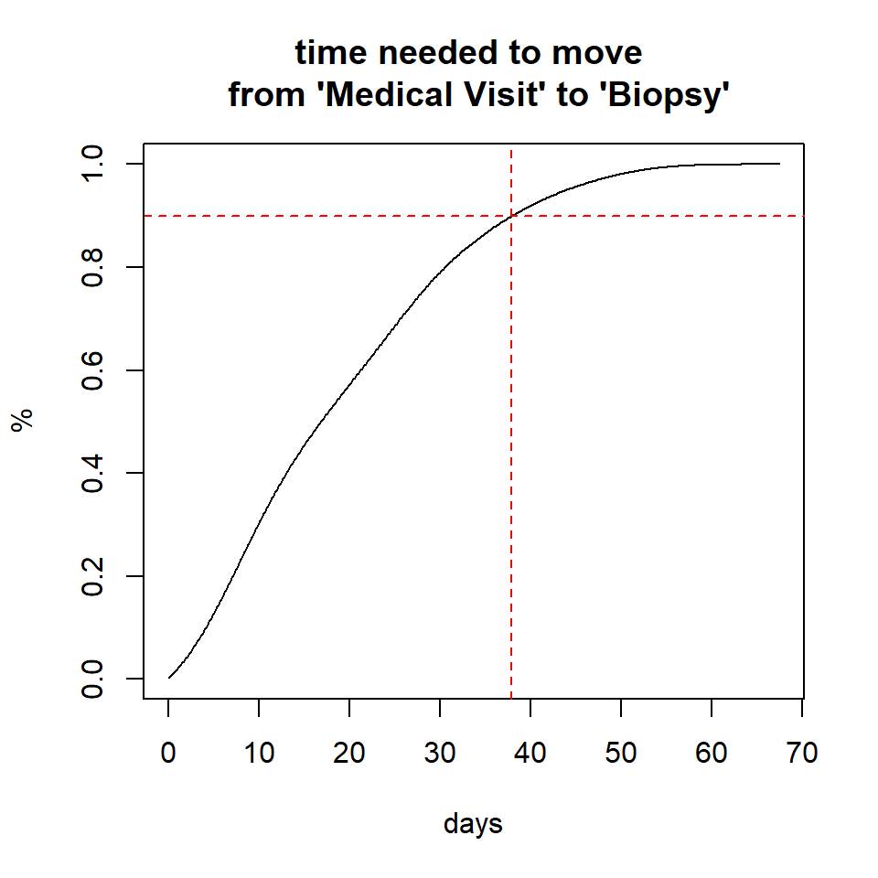

```r
# get the time and set it in days
measured.time <- objDL.out$MM.den.list.high.det$`Medical Visit`$Biopsy
measured.time <- measured.time / (60*24)
mes.time.dens <- density(measured.time,from=0)
# calculate the cumulative
cumulative.y.values <- cumsum(mes.time.dens$y )/max(cumsum(mes.time.dens$y ))
# plot it
plot(x = mes.time.dens$x, y = cumulative.y.values, type='l', xlab="days", ylab="%", main="time needed to move \n from 'Medical Visit' to 'Biopsy'")
ooo <- length(which((cumulative.y.values <= 0.9) == TRUE))
abline(v=mes.time.dens$x[ooo],col='red',lty=2)
abline(h=0.9,col='red', lty=2)
```

## 1.3 Plotting the Patient’s timeline

To have a first, raw, rude but practical overview of a single trace, the method *dataLoder::plotPatientTimeline()* can be used.

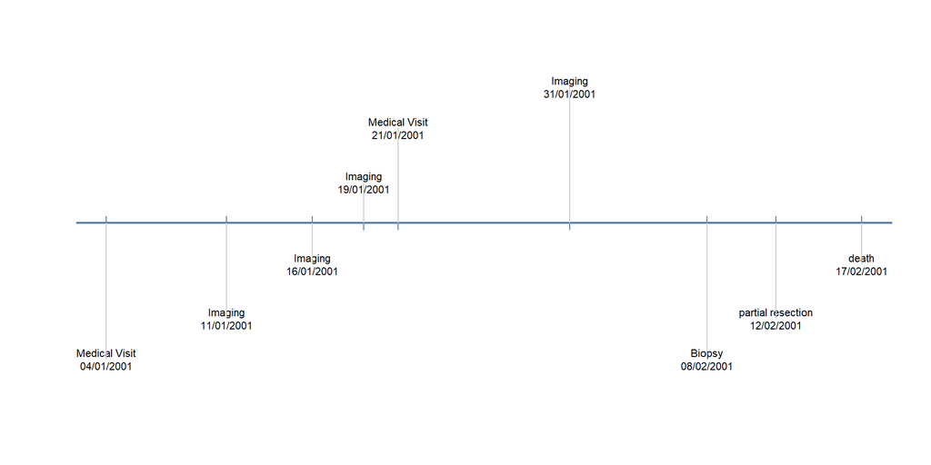

```r
 objDL$plotPatientTimeline(PatID = "1")
```

## 1.4 Filtering

Sometimes we might need to remove some Patients or some Events, on the base of something (e.g. an attribute value, etc..). To do that, the class *dataLoder* presents the method *dataLoder::applyFilter()* which can work in many ways on the base of the passed parameters:

- *array.events.to.keep* : filling this array we can say which Events have to be kept. All the others will be removed.
- *array.events.to.remove* : filling this array we can say which Events have to be removed. All the others will be kept.
- *array.pazienti.to.keep* : filling this array we can say which Patients have to be kept. All the others will be removed.
- *array.pazienti.to.removed* : filling this array we can say which Patients have to be removed. All the others will be kept.
- *remove.events.by.attribute.name* : here we can specify the name of an attribute (a column name) which will be used to filters the events. On the base of this only the corresponding events will be removed.
- *remove.patients.by.attribute.name* : this is similar to the previous one, but will remove the entire patient from the Event Log.
- *keep.events.by.attribute.name* : this works in the same way of *remove.events.by.attribute.name* but keep the event instead of removing it.
- *keep.patients.by.attribute.name* : this works in the same way of *remove.patients.by.attribute.name* but keep the patient instead of removing him
- *by.arr.attribute.value* : this contains the attribute value which will be used togheter with *remove.events.by.attribute.name*, *remove.patients.by.attribute.name*, *keep.events.by.attribute.name* or *keep.patients.by.attribute.name* to filter the events/patients.
- *whatToReturn* : specifies what should be returned. If set to “dataLoder” a new filtered *dataLoder* object will be returned, if set to “csv” a new filtered csv will be returned. If left BLANK (default value) the object itself will be filtered.

Here there are some practical examples.

### 1.4.1 getting the csv of the first 10 patients

we can get the first 10 Patient’s ID

```r
arr.ID <- names(objDL.out$pat.process)[1:10]
csvTable <- objDL$applyFilter(array.pazienti.to.keep = arr.ID,whatToReturn = "csv")
```

### 1.4.2 Dropping the males

To drop the males we have to remove the patients where the attribute *Sex* is set to *M*:

```r
newDL <- objDL$applyFilter(remove.patients.by.attribute.name = "Sex",by.arr.attribute.value = "M",whatToReturn = "dataLoader")
```

The variable *newDL* is now an instance of the class *dataLoder* filtered according to the patient’s sex. In this case we now have two ojbect: the former *objDL* which still keep the entire set of patients and *newDL* which is the filtered one.